# **Assignment 9**

In this assignment, you will use R (within R-Studio) to:

- Load and clean a real data set
- Conduct exploratory analyses, including informative figures
- Build and test appropriate models
- Draw conclusions about your data
- Combine all of the above into a well-documented R-Markdown report and export (knit) it into an HTML file

**All file paths should be relative, starting from *your* Assignment_9 directory!!**

**This means that you need to create a new R-Project named “Assignment_9.Rproj” in your Assignment_9 directory, and work from scripts within that.**

## **For credit…**

1. Push a completed version of your Rproj and R-markdown file (details at end of this assignment) to GitHub
2. Your score will also depend on your analyses and presentation of your final report

# Your tasks:

- Use the data set “/Data/GradSchool_Admissions.csv”
- You will explore and model the predictors of graduate school admission
  - the “admit” column is coded as 1=success and 0=failure (that’s binary, so model appropriately)
  - the other columns are the GRE score, the GPA, and the rank of the undergraduate institution, where I is “top-tier.”
- Document your data explorations, figures, and conclusions in a reproducible R-markdown report
- That means I want to see, in your html report, your process of model evaluation and selection. Here’s an [example](https://gzahn.github.io/data-course/Repository/Assignments/Assignment_9/example.html)
- Upload your **self-contained** R project, including knitted HTML report, to GitHub in *your* Assignment_9 directory

## Load Packages and Data

```r
library(tidyverse)
library(knitr)

grad <- read_csv("Data/GradSchool_Admissions.csv")
```

## Inspect the Data

```r
head(grad)
```

```
## # A tibble: 6 × 4
##   admit   gre   gpa  rank
##   <dbl> <dbl> <dbl> <dbl>
## 1     0   380  3.61     3
## 2     1   660  3.67     3
## 3     1   800  4        1
## 4     1   640  3.19     4
## 5     0   520  2.93     4
## 6     1   760  3        2
```

```r
View(grad)

summary(grad)
```

```
##      admit             gre             gpa             rank
##  Min.   :0.0000   Min.   :220.0   Min.   :2.260   Min.   :1.000
##  1st Qu.:0.0000   1st Qu.:520.0   1st Qu.:3.130   1st Qu.:2.000
##  Median :0.0000   Median :580.0   Median :3.395   Median :2.000
##  Mean   :0.3175   Mean   :587.7   Mean   :3.390   Mean   :2.485
##  3rd Qu.:1.0000   3rd Qu.:660.0   3rd Qu.:3.670   3rd Qu.:3.000
##  Max.   :1.0000   Max.   :800.0   Max.   :4.000   Max.   :4.000
```

## Missing Values

```r
colSums(is.na(grad))
```

```
## admit   gre   gpa  rank
##     0     0     0     0
```

## Prepare Variables

```r
grad$rank <- as.factor(grad$rank)
```

## Figure 1: Admissions

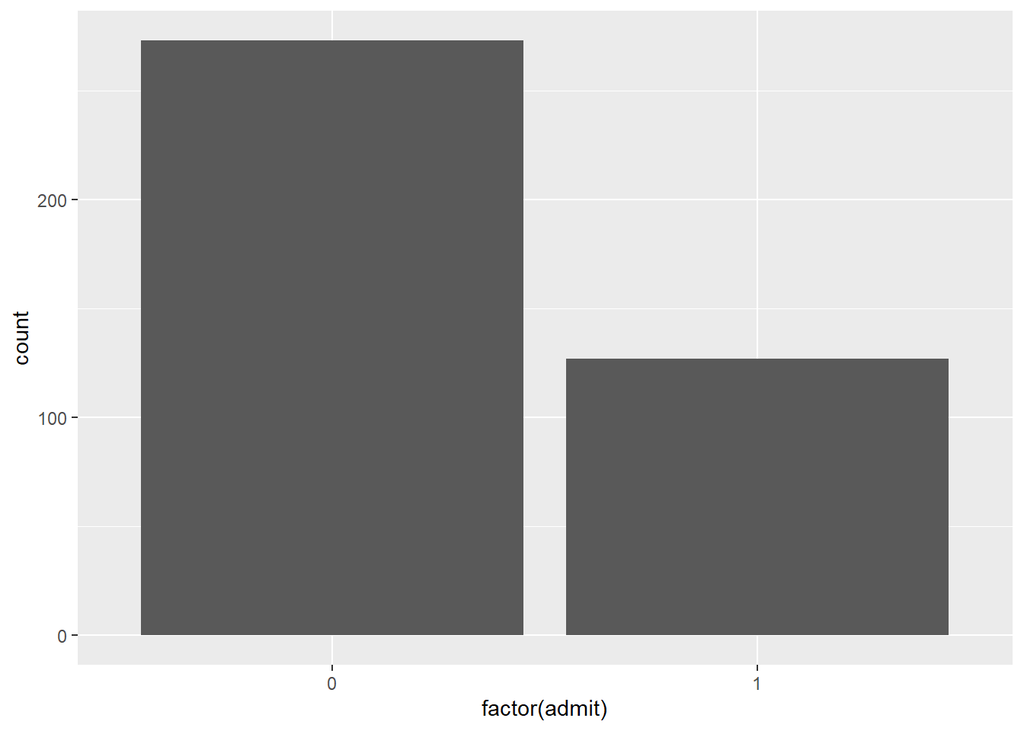

```r
ggplot(grad, aes(x = factor(admit))) +
  geom_bar()
```

## Figure 2: GPA by Admission Status

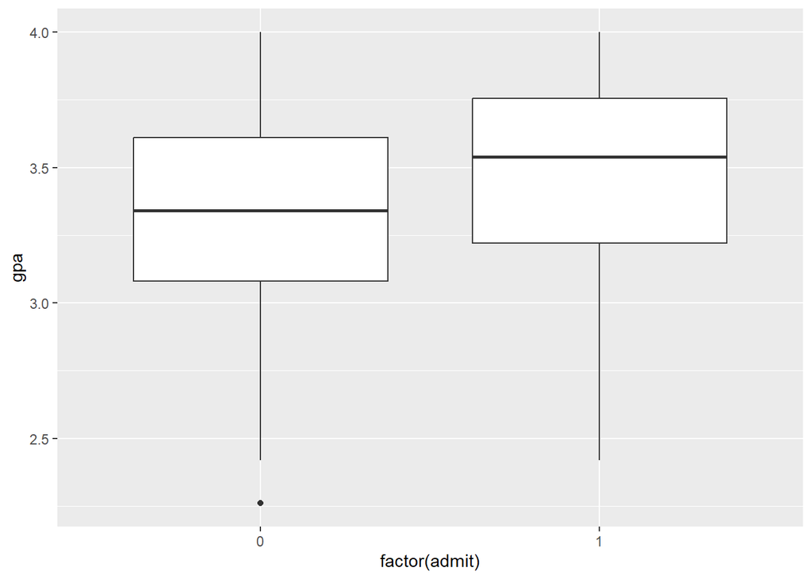

```r
ggplot(grad, aes(
  x = factor(admit),
  y = gpa
)) +
  geom_boxplot()
```

## Figure 3: GRE by Admission Status

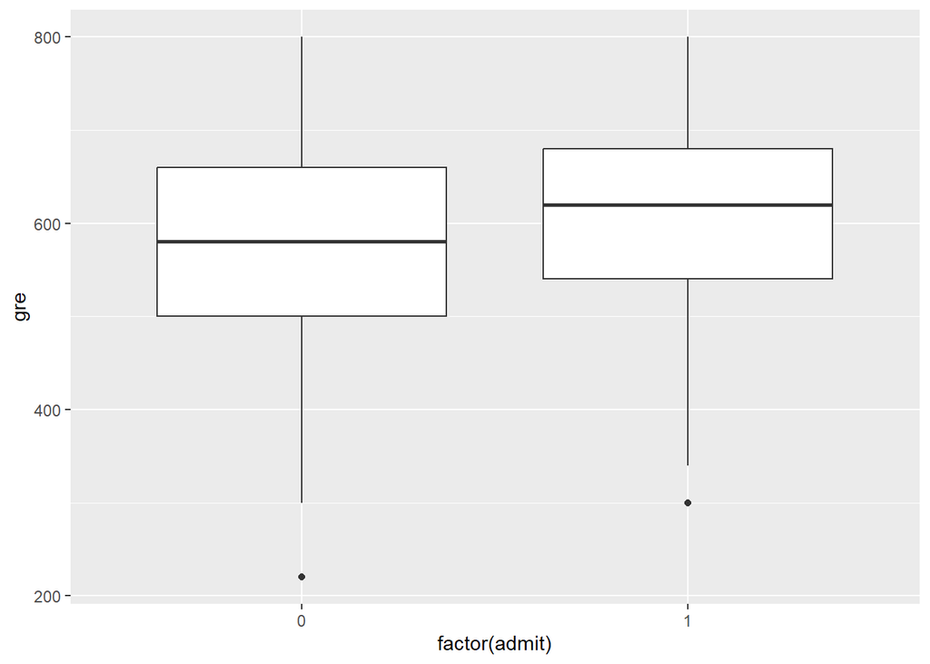

```r
ggplot(grad, aes(
  x = factor(admit),
  y = gre
)) +
  geom_boxplot()
```

## Figure 4: Admission by Rank

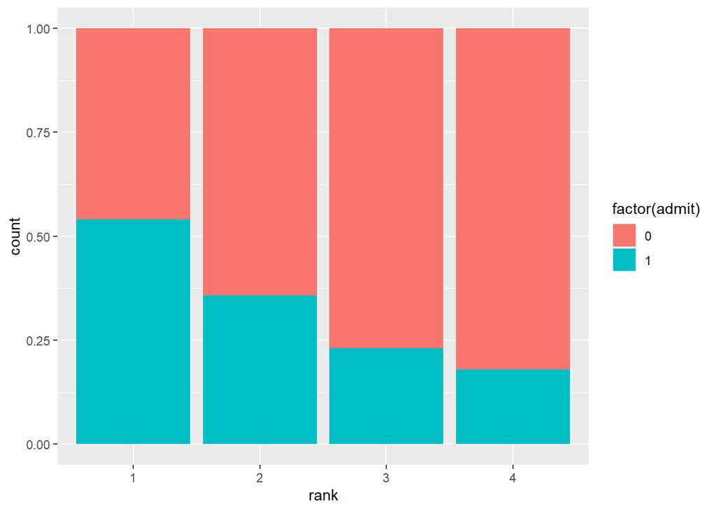

```r
ggplot(grad, aes(
  x = rank,
  fill = factor(admit)
)) +
  geom_bar(position = "fill")
```

## Logistic Regression Model

```r
model1 <- glm(
  admit ~ gre + gpa + rank,
  data = grad,
  family = "binomial"
)
```

## Model Summary

```r
summary(model1)
```

```
##
## Call:
## glm(formula = admit ~ gre + gpa + rank, family = "binomial",
##     data = grad)
##
## Coefficients:
##              Estimate Std. Error z value Pr(>|z|)
## (Intercept) -3.989979   1.139951  -3.500 0.000465 ***
## gre          0.002264   0.001094   2.070 0.038465 *
## gpa          0.804038   0.331819   2.423 0.015388 *
## rank2       -0.675443   0.316490  -2.134 0.032829 *
## rank3       -1.340204   0.345306  -3.881 0.000104 ***
## rank4       -1.551464   0.417832  -3.713 0.000205 ***
## ---
## Signif. codes:  0 '***' 0.001 '**' 0.01 '*' 0.05 '.' 0.1 ' ' 1
##
## (Dispersion parameter for binomial family taken to be 1)
##
##     Null deviance: 499.98  on 399  degrees of freedom
## Residual deviance: 458.52  on 394  degrees of freedom
## AIC: 470.52
##
## Number of Fisher Scoring iterations: 4
```

## Odds Ratios

```r
exp(coef(model1))
```

```
## (Intercept)         gre         gpa       rank2       rank3       rank4
##   0.0185001   1.0022670   2.2345448   0.5089310   0.2617923   0.2119375
```

## Conclusions

The data were used to explore predictors of graduate school admission. There were no missing values in the dataset. The exploratory figures suggested that students with higher GPA and GRE scores were more likely to be admitted. Admission rates also differed across school ranks.

A logistic regression model was fit using GRE, GPA, and school rank as predictors. The model results showed that GRE score, GPA, and school rank were significant predictors of admission. Students with higher GRE scores and GPAs were more likely to be admitted. Students from lower-ranked schools had lower odds of admission compared to students from rank 1 schools.

Overall, GRE, GPA, and school rank were all important predictors of graduate school admission.